# **Video Game Success Through the Lens of Sales and Reviews**

Members: Sharon Yin, Kyra Zhu

Webpage: https://zzzyx21.github.io

### **Motivation**

As the gaming industry continues to flourish, it stands as a vibrant and influential force in today's cultural landscape. Recognizing that the success of a video game goes beyond mere entertainment, we delve into understanding the intricate factors that contribute to its triumph.

Among these factors, sales and reviews emerge as pivotal metrics. Sales represent more than just revenue; they serve as a testament to a game's commercial viability, reflecting its resonance with consumer preferences, quality, and overall impact. Positive reviews, on the other hand, not only bolster a game's reputation but also shape its future success. Achieving a harmonious balance between sales performance and critical acclaim is crucial for developers and publishers alike.

From a data science perspective, exploring the dynamics of video game success presents a compelling and practical endeavor. With access to rich datasets containing variables such as sales figures, critic scores, and genre classifications, we have the opportunity to unveil hidden patterns, correlations, and predictive models through sophisticated statistical analyses, data visualization techniques, and advanced modeling approaches.

Therefore, we embark on this video game analysis journey, aiming to gain deeper insights into the interplay between sales and reviews. By leveraging these invaluable metrics, we not only navigate the competitive landscape of the gaming industry but also hone our understanding of what drives a game's triumph in today's digital age.

### **Datasets**

These datasets are ideal for our analysis, offering comprehensive insights into video game sales and associated factors. By exploring this data, we aim to uncover valuable insights into the popularity of video games, as well as trends and prediction in sales and critical reception over time.

Therefore, we'll investigate three main questions:

1. What is the relationship/correlation between critic scores and total sales?
2. What is the distrubution of sales, reviews, and prices of general video games and Steam game?
3. Can we predict a game's sales according to its reviews?

**Data source**

Bayne Brannen, and Asaniczka. (2024). Video Game Sales 2024 [Data set]. Kaggle. https://doi.org/10.34740/KAGGLE/DSV/7507070

Kanchana1990. (2024a, February 6). Steam store 2024: Hot Picks & reviews 💨. Kaggle. https://www.kaggle.com/datasets/kanchana1990/steam-store-2024-hot-picks-and-reviews

```python
%cd /content
!git clone https://github.com/zzzyx21/zzzyx21.github.io.git
%cd /content/zzzyx21.github.io
import pandas as pd
import numpy as np
import matplotlib.pyplot as plt
import seaborn as sns
from sklearn.model_selection import train_test_split
from sklearn.linear_model import LinearRegression
from sklearn.metrics import mean_squared_error, r2_score
from sklearn.preprocessing import OneHotEncoder
from sklearn.compose import ColumnTransformer
from sklearn.pipeline import Pipeline
from sklearn.impute import SimpleImputer
```

```
/content
Cloning into 'zzzyx21.github.io'...
remote: Enumerating objects: 34, done.
remote: Counting objects: 100% (34/34), done.
remote: Compressing objects: 100% (22/22), done.
remote: Total 34 (delta 16), reused 25 (delta 10), pack-reused 0
Receiving objects: 100% (34/34), 2.96 MiB | 8.30 MiB/s, done.
Resolving deltas: 100% (16/16), done.
/content/zzzyx21.github.io
```

## Video Game Sales Dataset

We imported the first dataset and labeled it as *games*. Then, we filtered and retained only the necessary information, as demonstrated in the code, dropping irrelevant columns such as image, publisher, and release & last update dates.

```python
games = pd.read_csv("./vgchartz-2024.csv", encoding="ISO-8859-1")
games = games[["title", "console", "genre", "critic_score", "total_sales", "na_sales", "jp_sales", "pal_sales", "other_sales", "release_date"]]
games
```

|  | title | console | genre | critic_score | total_sales | na_sales | jp_sales | pal_sales | other_sales | release_date |
| --- | --- | --- | --- | --- | --- | --- | --- | --- | --- | --- |
| 0 | 140 | PC | Platform | NaN | NaN | NaN | NaN | NaN | NaN | 2013/10/16 |
| 1 | 140 | WiiU | Platform | NaN | NaN | NaN | NaN | NaN | NaN | NaN |
| 2 | 757 | PC | Simulation | NaN | NaN | NaN | NaN | NaN | NaN | NaN |
| 3 | 1849 | OSX | Misc | NaN | NaN | NaN | NaN | NaN | NaN | 2014/07/01 |
| 4 | 1849 | PC | Misc | NaN | NaN | NaN | NaN | NaN | NaN | 2014/07/01 |
| ... | ... | ... | ... | ... | ... | ... | ... | ... | ... | ... |
| 64011 | Zwei!! | PSP | Role-Playing | NaN | 0.02 | NaN | 0.02 | NaN | NaN | 2008/12/11 |
| 64012 | Zwei!! | PS2 | Role-Playing | NaN | NaN | NaN | NaN | NaN | NaN | 2004/08/26 |
| 64013 | Zwei!! | PC | Role-Playing | NaN | NaN | NaN | NaN | NaN | NaN | 2001/01/01 |
| 64014 | Zyklus | PC | Adventure | NaN | NaN | NaN | NaN | NaN | NaN | 2003/04/30 |
| 64015 | Zyuden Sentai Kyoryuger: Game on Gaburincho | 3DS | Action | NaN | 0.05 | NaN | 0.05 | NaN | NaN | 2013/08/08 |

64016 rows × 10 columns

For preprocessing, we want to clean the data so we remove NaN data from our dataset to avoid noise. Initially, we identify games where critic score and total sales data are NaN. Then, we utilize the .dropna() function to accomplish this task.

```python
# Dropping rows where all specified columns are NaN
columns_to_check = ['critic_score','total_sales']
games = games.dropna(subset=columns_to_check)
regions_to_check = ['na_sales', 'jp_sales', 'pal_sales', 'other_sales']
games = games.dropna(subset=regions_to_check, how="all")
games
```

|  | title | console | genre | critic_score | total_sales | na_sales | jp_sales | pal_sales | other_sales | release_date |
| --- | --- | --- | --- | --- | --- | --- | --- | --- | --- | --- |
| 33 | .hack//G.U. Vol.2//Reminisce | PS2 | Role-Playing | 6.2 | 0.23 | 0.11 | NaN | 0.09 | 0.03 | 2007/05/08 |
| 35 | .hack//G.U. Vol.3//Redemption | PS2 | Role-Playing | 5.7 | 0.17 | NaN | 0.17 | NaN | NaN | 2007/09/10 |
| 36 | .hack//Infection Part 1 | PS2 | Role-Playing | 7.7 | 1.27 | 0.49 | 0.26 | 0.38 | 0.13 | 2003/02/11 |
| 38 | .hack//Mutation Part 2 | PS2 | Role-Playing | 7.5 | 0.68 | 0.23 | 0.20 | 0.18 | 0.06 | 2003/05/07 |
| 39 | .hack//Outbreak Part 3 | PS2 | Role-Playing | 7.1 | 0.46 | 0.14 | 0.17 | 0.11 | 0.04 | 2003/09/09 |
| ... | ... | ... | ... | ... | ... | ... | ... | ... | ... | ... |
| 63919 | Zoo Tycoon DS | DS | Strategy | 4.6 | 0.98 | 0.86 | 0.01 | 0.03 | 0.07 | 2005/10/11 |
| 63934 | ZooCube | GBA | Puzzle | 8.6 | 0.05 | 0.03 | NaN | 0.01 | 0.00 | 2002/05/14 |
| 63935 | ZooCube | GC | Puzzle | 6.9 | 0.02 | 0.02 | NaN | 0.00 | 0.00 | 2002/05/05 |
| 63977 | Zubo | DS | Misc | 7.5 | 0.11 | 0.08 | NaN | 0.02 | 0.01 | 2009/03/10 |
| 63988 | Zuma's Revenge! | PC | Puzzle | 8.3 | 0.01 | 0.01 | NaN | NaN | 0.00 | 2009/09/16 |

4126 rows × 10 columns

Here is the summary statistics for the numerical columns after preprocessing:

```python
summary_statistics = games.describe()
summary_statistics
```

|  | critic_score | total_sales | na_sales | jp_sales | pal_sales | other_sales |
| --- | --- | --- | --- | --- | --- | --- |
| count | 4126.000000 | 4126.000000 | 3738.000000 | 1402.000000 | 3779.000000 | 4003.000000 |
| mean | 7.101890 | 0.737230 | 0.416581 | 0.108959 | 0.263697 | 0.083560 |
| std | 1.439307 | 1.408497 | 0.734706 | 0.162062 | 0.612218 | 0.199425 |
| min | 1.000000 | 0.000000 | 0.000000 | 0.000000 | 0.000000 | 0.000000 |
| 25% | 6.300000 | 0.110000 | 0.080000 | 0.020000 | 0.020000 | 0.010000 |
| 50% | 7.300000 | 0.300000 | 0.180000 | 0.050000 | 0.070000 | 0.020000 |
| 75% | 8.100000 | 0.750000 | 0.430000 | 0.130000 | 0.250000 | 0.080000 |
| max | 10.000000 | 20.320000 | 9.760000 | 1.870000 | 9.850000 | 3.120000 |

We proceed to generate the figure depicting the distribution of total sales. It's evident from the graph that the distribution is highly right-skewed.

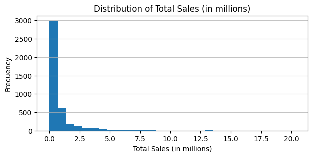

```python
plt.figure(figsize=(7,3))
plt.hist(games['total_sales'], bins=30)
plt.title('Distribution of Total Sales (in millions)')
plt.xlabel('Total Sales (in millions)')
plt.ylabel('Frequency')
plt.grid(axis='y', alpha=0.75)
```

In this bar plot, we observe that the majority of games have total sales ranging from 0.0 to 2.5 million units. This distribution is typical in sales data, where numerous products sell modestly, while a select few achieve significant success. To enhance clarity, we intend to apply a logarithmic scale to the graph.

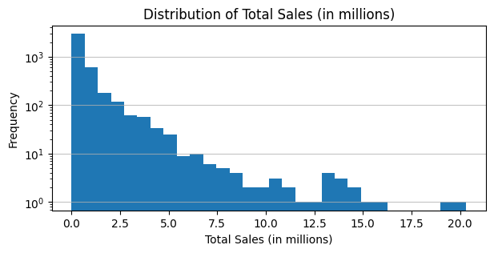

```python
plt.figure(figsize=(7,3))
plt.hist(games['total_sales'], bins=30, log = True)
plt.title('Distribution of Total Sales (in millions)')
plt.xlabel('Total Sales (in millions)')
plt.ylabel('Frequency')
plt.grid(axis='y', alpha=0.75)
```

The log-transformed plot provides a clear depiction of the distribution of game sales, offering insights into the sales pattern. It obviously reveals that the majority of games achieve moderate sales performance, with a notable presence of a few highly successful ones.

Next, we'll calculate the correlation between the critic score and total sales to determine their relationship.

```python
games["total_sales"].corr(games["critic_score"])
# a correlation coefficient of 0.28 is considered to be a weak correlation.
```

```
0.2811658100265469
```

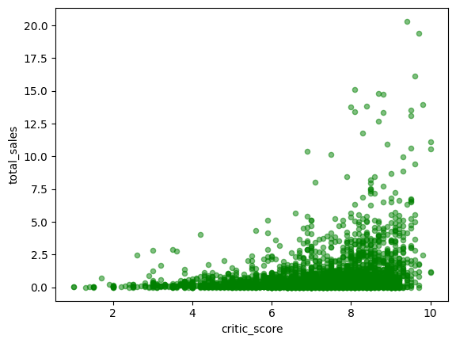

```python
games.plot.scatter(x="critic_score", y="total_sales", alpha=.5, color = 'green')
# There is a moderate positive correlation between critic scores and total sales.
```

A correlation coefficient of 0.28 could be considered as weak correlation between sales and critic score.

To determine which genre has the highest sales, we'll aggregate the sales figures for each genre and then create a plot illustrating the total sales for each genre. This visualization will provide a clear indication of which genre is the most successful in terms of sales.

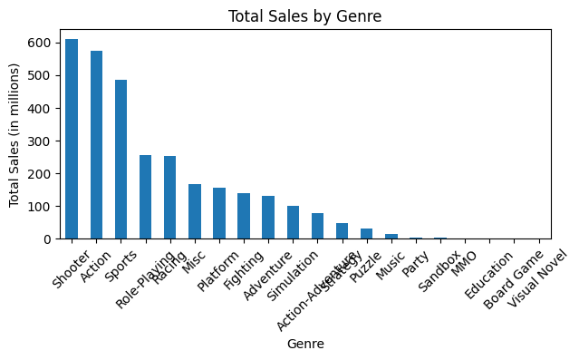

```
genre
Shooter             609.93
Action              574.34
Sports              484.90
Role-Playing        254.23
Racing              252.24
Misc                164.90
Platform            155.96
Fighting            138.59
Adventure           131.52
Simulation           99.43
Action-Adventure     76.36
Strategy             46.81
Puzzle               31.36
Music                13.37
Party                 2.99
Sandbox               1.89
MMO                   1.17
Education             0.61
Board Game            0.31
Visual Novel          0.03
Name: total_sales, dtype: float64
```

```python
# Sum the sales figures for each genre
genre_sales = games.groupby('genre')[['na_sales', 'jp_sales', 'pal_sales', 'other_sales']].sum()

# Add a total sales column for each genre
genre_sales['total_sales'] = genre_sales.sum(axis=1)

# Sort the genres by total sales
genre_sales_sorted = genre_sales.sort_values('total_sales', ascending=False)

# Plotting the total sales for each genre
plt.figure(figsize=(7,3))
genre_sales_sorted['total_sales'].plot(kind='bar')
plt.title('Total Sales by Genre')
plt.xlabel('Genre')
plt.ylabel('Total Sales (in millions)')
plt.xticks(rotation=45)
plt.show()

genre_sales_sorted['total_sales']
```

The bar chart visualizes the total sales by genre. Here are the key takeaways:

- The Shooter genre has the highest total sales, followed closely by the Action genre.
- The Sports genre is not far behind, ranking third in total sales.
- There's a notable drop in total sales from the top three genres to the Role-Playing and Racing genres, and further down the list.
- Genres like Party, Sandbox, MMO, Educatoin, Board Game, and Visual Novel have relatively much lower total sales.

Similarly, to determine which consoles have the highest sales, we sum the sales figures for each console and then visualize to compare.

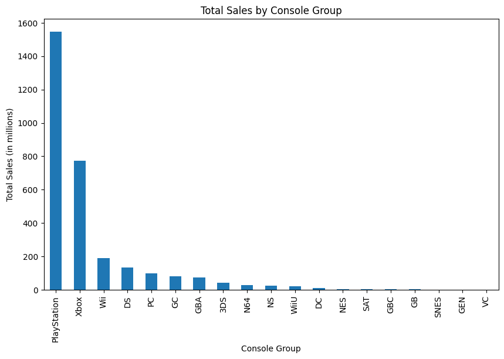

```
console_grouped
PlayStation    1546.15
Xbox            772.41
Wii             190.09
DS              133.28
PC               99.98
GC               80.58
GBA              75.08
3DS              43.92
N64              27.67
NS               25.20
WiiU             20.12
DC               10.68
NES               4.17
SAT               3.80
GBC               3.78
GB                3.31
SNES              0.53
GEN               0.19
VC                0.00
Name: total_sales, dtype: float64
```

```python
# Combine the steps for grouping PlayStation and Xbox consoles into a single cell

# Group all PlayStation consoles under a single 'PS' category and all Xbox consoles under 'Xbox'
games['console_grouped'] = games['console'].replace(
    {
        r'PS.*': 'PlayStation',  # Use regex to match any PlayStation variation
        r'X.*': 'Xbox'  # Use regex to match any Xbox variation
    },
    regex=True
)

# Recalculate the total sales figures for each console group
console_grouped_sales = games.groupby('console_grouped')[['na_sales', 'jp_sales', 'pal_sales', 'other_sales']].sum()
console_grouped_sales['total_sales'] = console_grouped_sales.sum(axis=1)

# Sort the console groups by total sales
console_grouped_sales_sorted = console_grouped_sales.sort_values('total_sales', ascending=False)

# Plotting the total sales for each console group in a single chart
plt.figure(figsize=(10, 6))
console_grouped_sales_sorted['total_sales'].plot(kind='bar')
plt.title('Total Sales by Console Group')
plt.xlabel('Console Group')
plt.ylabel('Total Sales (in millions)')
plt.xticks(rotation=90)
plt.show()

# Return the sorted total sales for further inspection if needed
console_grouped_sales_sorted['total_sales']
```

When grouped together, PlayStation consoles (across all generations) have the highest cumulative sales, underscoring the brand's strong presence and enduring popularity in the gaming market. The Xbox group ranks second, showcasing significant market penetration and success, particularly in western markets.

Next, we would like to find out which game has the highest critic score and highest sales by sorting the values using the data after cleaning.

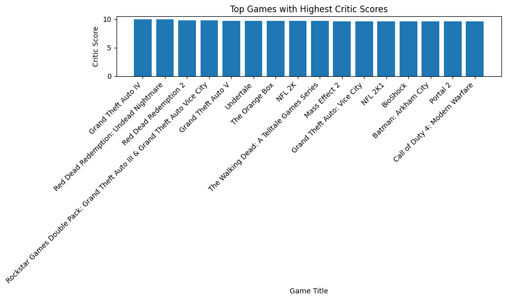

```python
# Select games with highest critic scores
top_games = games.sort_values(by='critic_score', ascending=False).head(20)

# Plot bar graph
plt.figure(figsize=(10, 6))
plt.bar(top_games['title'], top_games['critic_score'])
plt.title('Top Games with Highest Critic Scores')
plt.xlabel('Game Title')
plt.ylabel('Critic Score')
plt.xticks(rotation=45, ha='right')
plt.tight_layout()
plt.show()
```

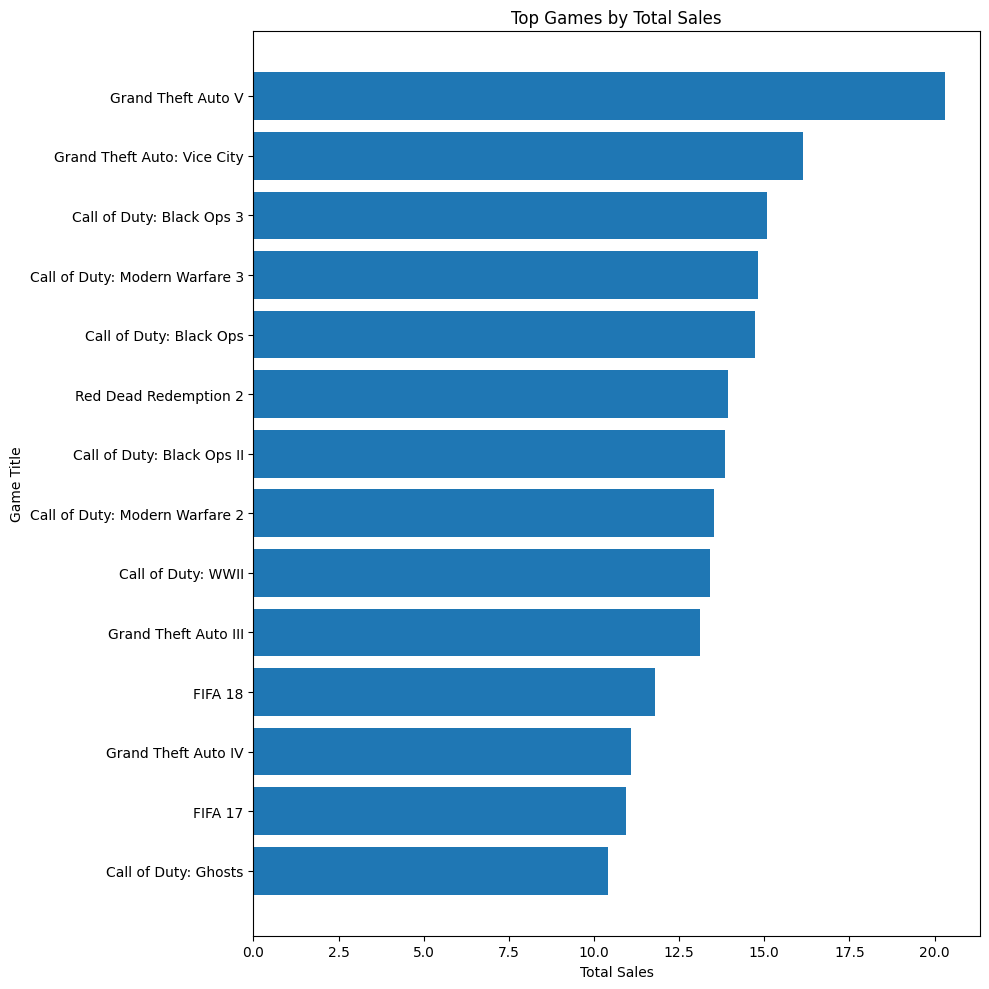

```python
# Sort by total sales in descending order
highest_sales_games = games.sort_values(by='total_sales', ascending=False).head(20)

# Plot horizontal bar graph
plt.figure(figsize=(10, 10))
plt.barh(highest_sales_games['title'], highest_sales_games['total_sales'])
plt.title('Top Games by Total Sales')
plt.xlabel('Total Sales')
plt.ylabel('Game Title')
plt.gca().invert_yaxis()  # Invert y-axis to display highest sales at the top
plt.tight_layout()
plt.show()
```

These graphs indicate that Grand Theft Auto IV receives the highest critic score, while Grand Theft Auto V achieves the highest sales across all regions. It's apparent that both the Grand Theft Auto series and the Red Dead Redemption series are consistently associated with high critic scores and sales figures, followed by the Call of Duty series.

We then explore how various factors impact total sales. Specifically, we'll examine the influence of factors such as console, genre, critic score, and release date on total sales. By analyzing their relationships, we can gain insights into the drivers behind total sales in the video game industry.

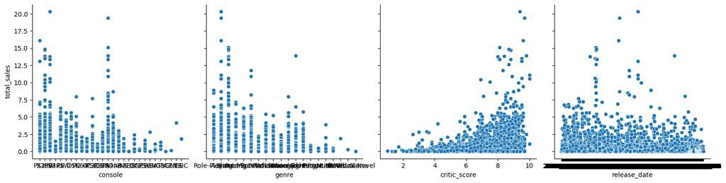

```python
# Create a pairplot with total sales against console, genre, critic score, and release date
sns.pairplot(games, x_vars=["console", "genre", "critic_score", "release_date"], y_vars=["total_sales"], kind='scatter', height=4)
plt.show()
```

Here is a summary of different features that are corresponding to the total sales.

## Steam Store Game Dataset

We now read in the second table and name it as *steam*.

```python
steam = pd.read_csv("./steam_store_data_2024.csv")
steam = steam[["title", "price", "allReviews"]]
steam
```

|  | title | price | allReviews |
| --- | --- | --- | --- |
| 0 | 100 Ninja Cats | NaN | NaN |
| 1 | And the Hero Was Never Seen Again | NaN | NaN |
| 2 | Tycoon Collection | NaN | NaN |
| 3 | Arzette: The Jewel of Faramore | NaN | NaN |
| 4 | Atomic Heart | $29.99 | Mostly Positive |
| ... | ... | ... | ... |
| 81 | ULTROS | $22.49 | NaN |
| 82 | Uncharted: Legacy of Thieves Collection | $24.99 | Very Positive |
| 83 | Undying | $13.99 | Mostly Positive |
| 84 | Vampire: The Masquerade - Bloodlines 2 | NaN | NaN |
| 85 | WitchHand | NaN | NaN |

86 rows × 3 columns

We change the all reviews to numeric that can be easier for us to analyze later. Overwhelmingly positive points to 9 scores, Very Positive points to 8 scores and so on.

```python
ratings_map = {
    'Overwhelmingly Positive': 9,
    'Very Positive': 8,
    'Positive': 7,
    'Mostly Positive': 6,
    'Mixed': 5,
    'Mostly Negative': 4,
    'Negative': 3,
    'Very Negative': 2,
    'Overwhelmingly Negative': 1
}

steam['allReviews'] = steam['allReviews'].replace(ratings_map)
steam
```

|  | title | price | allReviews |
| --- | --- | --- | --- |
| 0 | 100 Ninja Cats | NaN | NaN |
| 1 | And the Hero Was Never Seen Again | NaN | NaN |
| 2 | Tycoon Collection | NaN | NaN |
| 3 | Arzette: The Jewel of Faramore | NaN | NaN |
| 4 | Atomic Heart | $29.99 | 6.0 |
| ... | ... | ... | ... |
| 81 | ULTROS | $22.49 | NaN |
| 82 | Uncharted: Legacy of Thieves Collection | $24.99 | 8.0 |
| 83 | Undying | $13.99 | 6.0 |
| 84 | Vampire: The Masquerade - Bloodlines 2 | NaN | NaN |
| 85 | WitchHand | NaN | NaN |

86 rows × 3 columns

Delete the $ sign in the 'price'* column and convert this column figures to float number.

```python
steam['price'] = steam['price'].astype(str)
steam['price'] = steam['price'].str.replace('$', '', regex = False)
steam['price'] = steam['price'].astype('float64')
steam
```

|  | title | price | allReviews |
| --- | --- | --- | --- |
| 0 | 100 Ninja Cats | NaN | NaN |
| 1 | And the Hero Was Never Seen Again | NaN | NaN |
| 2 | Tycoon Collection | NaN | NaN |
| 3 | Arzette: The Jewel of Faramore | NaN | NaN |
| 4 | Atomic Heart | 29.99 | 6.0 |
| ... | ... | ... | ... |
| 81 | ULTROS | 22.49 | NaN |
| 82 | Uncharted: Legacy of Thieves Collection | 24.99 | 8.0 |
| 83 | Undying | 13.99 | 6.0 |
| 84 | Vampire: The Masquerade - Bloodlines 2 | NaN | NaN |
| 85 | WitchHand | NaN | NaN |

86 rows × 3 columns

To preprocess, we check how many data has no value and duplicates.

```python
steam.isna().sum()
```

```
title          0
price         25
allReviews    29
dtype: int64
```

```python
steam.dropna(inplace=True) # Drops rows with any NaN value
steam.drop_duplicates(subset='title')
steam
```

|  | title | price | allReviews |
| --- | --- | --- | --- |
| 4 | Atomic Heart | 29.99 | 6.0 |
| 6 | Bendy and the Dark Revival | 5.99 | 8.0 |
| 7 | Bendy and the Dark Revival | 5.99 | 8.0 |
| 8 | BlazBlue | 17.15 | 6.0 |
| 9 | Boxes: Lost Fragments | 13.49 | 8.0 |
| 10 | CARRION | 5.99 | 8.0 |
| 11 | CARRION | 5.99 | 8.0 |
| 15 | Crisis Core: Final Fantasy VII Reunion | 29.99 | 8.0 |
| 16 | Days Gone | 12.49 | 8.0 |
| 17 | Dead by Daylight | 7.99 | 8.0 |
| 18 | Dead by Daylight | 7.99 | 8.0 |
| 19 | Dead Space | 23.99 | 8.0 |
| 21 | Destiny 2 | 14.99 | 6.0 |
| 22 | Destiny 2: Lightfall + Annual Pass | 33.00 | 4.0 |
| 23 | Dragon Quest XI: Echoes of an Elusive Age | 23.99 | 8.0 |
| 24 | Dragon Quest XI: Echoes of an Elusive Age | 23.99 | 8.0 |
| 25 | Fallout 76 | 9.99 | 6.0 |
| 27 | Final Fantasy VII Remake Intergrade | 34.99 | 8.0 |
| 28 | Final Fantasy VII Remake Intergrade | 34.99 | 8.0 |
| 29 | Final Fantasy X / X-2 HD Remaster | 11.99 | 8.0 |
| 30 | Final Fantasy XII: The Zodiac Age | 19.99 | 8.0 |
| 31 | Final Fantasy XV: Windows Edition | 13.99 | 8.0 |
| 32 | Flashing Lights - Police, Firefighting, Emerge... | 8.49 | 8.0 |
| 33 | Flashing Lights - Police, Firefighting, Emerge... | 8.49 | 8.0 |
| 35 | God of War | 24.99 | 9.0 |
| 36 | Grounded | 26.79 | 8.0 |
| 38 | Halo Infinite | 23.99 | 6.0 |
| 39 | Halo Infinite (Campaign) | 23.99 | 5.0 |
| 40 | Headbangers: Rhythm Royale | 13.39 | 8.0 |
| 41 | Hell Let Loose | 42.24 | 8.0 |
| 42 | HELLCARD | 15.79 | 8.0 |
| 45 | Hogwarts Legacy | 35.99 | 8.0 |
| 46 | Hogwarts Legacy | 35.99 | 8.0 |
| 49 | Last Train Home | 26.39 | 8.0 |
| 50 | LEGO Star Wars: The Complete Saga | 4.99 | 9.0 |
| 54 | Marvel’s Spider-Man Remastered | 35.99 | 8.0 |
| 55 | Marvel’s Spider-Man: Miles Morales | 29.99 | 8.0 |
| 56 | Moonbreaker | 22.49 | 8.0 |
| 58 | Ori and the Will of the Wisps | 9.89 | 9.0 |
| 59 | Ori and the Will of the Wisps | 9.89 | 9.0 |
| 60 | Overcooked! 2 | 6.24 | 8.0 |
| 61 | Poppy Playtime - Chapter 3 | 9.89 | 8.0 |
| 62 | Ratchet & Clank: Rift Apart | 40.19 | 8.0 |
| 63 | Ready or Not | 37.49 | 6.0 |
| 64 | Ready or Not | 37.49 | 6.0 |
| 65 | Returnal | 40.19 | 8.0 |
| 69 | Star Wars Battlefront II | 3.49 | 8.0 |
| 70 | Star Wars: The Force Unleashed - Ultimate Sith... | 6.99 | 8.0 |
| 71 | Star Wars: Empire at War - Gold Pack | 6.99 | 9.0 |
| 72 | Stranger of Paradise: Final Fantasy Origin | 23.99 | 8.0 |
| 73 | The Elder Scrolls V: Skyrim Special Edition | 9.99 | 8.0 |
| 75 | Thronefall | 5.24 | 9.0 |
| 76 | Thronefall | 5.24 | 9.0 |
| 77 | Thymesia | 14.99 | 8.0 |
| 78 | Thymesia | 14.99 | 8.0 |
| 82 | Uncharted: Legacy of Thieves Collection | 24.99 | 8.0 |
| 83 | Undying | 13.99 | 6.0 |

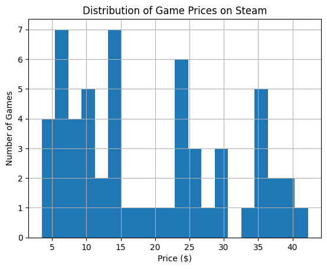

```python
# Cleaning the price data to remove the dollar sign and convert it to float
steam['price'] = steam['price'].replace('[\$,]', '', regex=True).astype(float)

# Plotting the histogram of prices
steam['price'].hist(bins=20)
plt.title('Distribution of Game Prices on Steam')
plt.xlabel('Price ($)')
plt.ylabel('Number of Games')
plt.show()
```

After cleaning the data, we have this plot of the distribution of game prices on Steam.

Next, we'll narrow our focus to PC games from the first dataset *games*. We'll filter out PC games from this dataset and then merge the filtered dataset with the *steam* data. Since Steam games are specifically for the PC platform, this merge will allow us to conduct further analysis on PC games.

```python
games = pd.read_csv("./vgchartz-2024.csv", encoding="ISO-8859-1")
games = games[["title", "console", "genre", "critic_score", "total_sales", "na_sales", "jp_sales", "pal_sales", "other_sales"]]


steam = pd.read_csv("./steam_store_data_2024.csv")
steam = steam[["title", "price", "allReviews"]]
steam

ratings_map = {
    'Overwhelmingly Positive': 9,
    'Very Positive': 8,
    'Positive': 7,
    'Mostly Positive': 6,
    'Mixed': 5,
    'Mostly Negative': 4,
    'Negative': 3,
    'Very Negative': 2,
    'Overwhelmingly Negative': 1
}

steam['allReviews'] = steam['allReviews'].replace(ratings_map)
steam['price'] = steam['price'].astype(str)
steam['price'] = steam['price'].str.replace('$', '', regex = False)
steam['price'] = steam['price'].astype('float64')

steam

games = games[["title", "console", "genre"]]
pc_games_vgchartz = games[games['console'] == 'PC']

# Merge the filtered PC games dataset with the Steam data
pc_merged_data = pd.merge(steam, pc_games_vgchartz, on='title', how='inner')
pc_merged_data = pc_merged_data.drop_duplicates(subset='title')
pc_merged_data['price'] = pc_merged_data['price'].fillna(pc_merged_data['price'].mean())
pc_merged_data['allReviews'] = pc_merged_data['allReviews'].fillna(pc_merged_data['allReviews'].mean())

pc_merged_data
```

|  | title | price | allReviews | console | genre |
| --- | --- | --- | --- | --- | --- |
| 0 | Tycoon Collection | 22.224375 | 7.714286 | PC | Strategy |
| 1 | Atomic Heart | 29.990000 | 6.000000 | PC | Shooter |
| 2 | Banishers: Ghosts of New Eden | 49.990000 | 7.714286 | PC | Role-Playing |
| 3 | Crisis Core: Final Fantasy VII Reunion | 29.990000 | 8.000000 | PC | Role-Playing |
| 4 | Days Gone | 12.490000 | 8.000000 | PC | Action-Adventure |
| 5 | Dead by Daylight | 7.990000 | 8.000000 | PC | Action |
| 7 | Dead Space | 23.990000 | 8.000000 | PC | Shooter |
| 8 | Deep Rock Galactic | 22.224375 | 7.714286 | PC | Shooter |
| 9 | Destiny 2 | 14.990000 | 6.000000 | PC | Shooter |
| 10 | Fallout 76 | 9.990000 | 6.000000 | PC | Role-Playing |
| 11 | Fight Crab | 22.224375 | 7.714286 | PC | Action |
| 12 | Final Fantasy X / X-2 HD Remaster | 11.990000 | 8.000000 | PC | Role-Playing |
| 13 | Final Fantasy XII: The Zodiac Age | 19.990000 | 8.000000 | PC | Role-Playing |
| 14 | Final Fantasy XV: Windows Edition | 13.990000 | 8.000000 | PC | Role-Playing |
| 15 | Goat Simulator | 22.224375 | 7.714286 | PC | Misc |
| 16 | God of War | 24.990000 | 9.000000 | PC | Action-Adventure |
| 17 | Grounded | 26.790000 | 8.000000 | PC | Action-Adventure |
| 18 | Gunvolt Records Cychronicle | 22.224375 | 7.714286 | PC | Music |
| 19 | Halo Infinite | 23.990000 | 6.000000 | PC | Shooter |
| 20 | Helldivers 2 | 59.990000 | 7.714286 | PC | Shooter |
| 21 | Hogwarts Legacy | 35.990000 | 8.000000 | PC | Role-Playing |
| 23 | Last Train Home | 26.390000 | 8.000000 | PC | Strategy |
| 24 | LEGO Star Wars: The Complete Saga | 4.990000 | 9.000000 | PC | Misc |
| 25 | Ori and the Will of the Wisps | 9.890000 | 9.000000 | PC | Action-Adventure |
| 27 | Ratchet & Clank: Rift Apart | 40.190000 | 8.000000 | PC | Action-Adventure |
| 28 | Ready or Not | 37.490000 | 6.000000 | PC | Shooter |
| 30 | Returnal | 40.190000 | 8.000000 | PC | Shooter |
| 31 | Star Wars Battlefront II | 3.490000 | 8.000000 | PC | Shooter |
| 32 | Star Wars: The Force Unleashed - Ultimate Sith... | 6.990000 | 8.000000 | PC | Action |
| 33 | Star Wars: Empire at War - Gold Pack | 6.990000 | 9.000000 | PC | Strategy |
| 34 | Stranger of Paradise: Final Fantasy Origin | 23.990000 | 8.000000 | PC | Action |
| 35 | The Elder Scrolls V: Skyrim Special Edition | 9.990000 | 8.000000 | PC | Role-Playing |
| 36 | Nicolas Eymerich - The Inquisitor | 22.224375 | 7.714286 | PC | Misc |
| 37 | Thymesia | 14.990000 | 8.000000 | PC | Role-Playing |
| 39 | Tomb Raider I-III Remastered | 26.990000 | 7.714286 | PC | Action-Adventure |
| 40 | ULTROS | 22.490000 | 7.714286 | PC | Action-Adventure |
| 41 | Uncharted: Legacy of Thieves Collection | 24.990000 | 8.000000 | PC | Action-Adventure |
| 42 | Undying | 13.990000 | 6.000000 | PC | Adventure |
| 43 | Vampire: The Masquerade - Bloodlines 2 | 22.224375 | 7.714286 | PC | Action |

```python
pc_merged_data.shape
```

```
(39, 5)
```

First, we'll visualize the distribution of game prices to understand the pricing landscape for PC games on Steam.

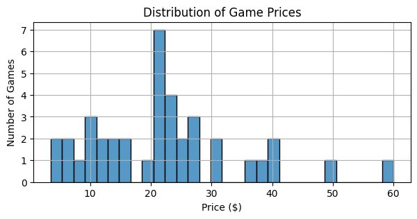

```python
plt.figure(figsize=(7, 3))
sns.histplot(pc_merged_data['price'], bins=30)
plt.title('Distribution of Game Prices')
plt.xlabel('Price ($)')
plt.ylabel('Number of Games')
plt.grid(True)
plt.show()
```

Moving forward, we'll analyze the correlation between review scores and prices to determine if higher-priced games generally receive better reviews.

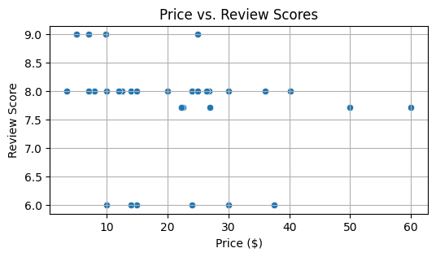

```python
plt.figure(figsize=(6, 3))
sns.scatterplot(data=pc_merged_data, x='price', y='allReviews')
plt.title('Price vs. Review Scores')
plt.xlabel('Price ($)')
plt.ylabel('Review Score')
plt.grid(True)
plt.show()

reg_model = LinearRegression()
reg_model.fit(pc_merged_data[['price']], pc_merged_data['allReviews'])

# Predict review scores using the linear regression model
predicted_reviews = reg_model.predict(pc_merged_data[['price']])
```

According to this figure, the review scores appear to be generally high across all price ranges, indicating that price is not a direct indicator of higher satisfaction or quality perception among players.

Also, many games, irrespective of price, have received high review scores (8-9), suggesting that quality experiences are available across various price points.

However, we found that this graph doesn't provide us a clear trend or correlation between price and review scores. The points are fairly evenly distributed across the range of prices, with most of the review scores hovering around the same region, regardless of the game's price. This suggests that there is little to no linear relationship between the price of the games on Steam and their review scores.

We now explore which genres are most common and how they vary in terms of pricing and reviews. This will give us insights into market trends and consumer preferences.

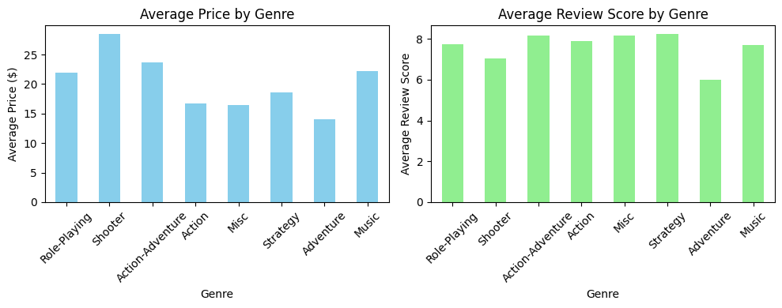

| genre | Count |
| --- | --- |
| Role-Playing | 9 |
| Shooter | 9 |
| Action-Adventure | 8 |
| Action | 5 |
| Misc | 3 |
| Strategy | 3 |
| Adventure | 1 |
| Music | 1 |

```python
# Group by genre and calculate average price and average review score
genre_analysis = pc_merged_data.groupby('genre').agg(
    Average_Price=('price', 'mean'),
    Average_Review_Score=('allReviews', 'mean'),
    Count=('title', 'count')
).sort_values(by='Count', ascending=False)

# Plotting average price and review score by genre
fig, axes = plt.subplots(nrows=1, ncols=2, figsize=(10, 4))
genre_analysis['Average_Price'].plot(kind='bar', ax=axes[0], color='skyblue')
axes[0].set_title('Average Price by Genre')
axes[0].set_xlabel('Genre')
axes[0].set_ylabel('Average Price ($)')
axes[0].tick_params(axis='x', rotation=45)

genre_analysis['Average_Review_Score'].plot(kind='bar', ax=axes[1], color='lightgreen')
axes[1].set_title('Average Review Score by Genre')
axes[1].set_xlabel('Genre')
axes[1].set_ylabel('Average Review Score')
axes[1].tick_params(axis='x', rotation=45)

plt.tight_layout()
plt.show()

# Display the genre analysis for number of games per genre
genre_analysis[['Count']]
```

# Modeling Approach for Different Features Suggesting Total Sales

## Data Preparation

The success of any predictive modeling project hinges on robust data preparation. For this analysis, we began by cleaning the video game sales data sourced from Kaggle and the Steam Store, ensuring completeness by removing entries with missing values in critical fields such as console, genre, critic score, release date, and total sales. We then extracted relevant features for our prediction models: game titles, consoles, genres, critic scores, release dates, and sales figures.

## Feature Engineering

To enhance the predictive power of our models, we transformed categorical data (e.g., console and genre) using one-hot encoding, allowing models to better capture the impact of different categories on sales. Numerical data (e.g., critic scores) were standardized to bring them onto a comparable scale, mitigating any bias towards variables with larger ranges.

## Model Selection

We selected two distinct types of regression models to predict video game sales: RandomForest and K-Nearest Neighbors (KNN), each with its strengths and computational considerations.

## RandomForest Regressor

**Rationale:** Capable of handling complex nonlinear relationships and interactions between features without extensive hyperparameter tuning. It's robust against overfitting, especially with many trees in the forest. **Configuration:** We configured the RandomForest with 100 trees and used random state 42 for reproducibility. **Strengths:** Excellent at capturing complex patterns in the data, provides feature importance metrics, and is generally less sensitive to outliers. **Limitations:** Computationally intensive, not as interpretable as simpler models.

## K-Nearest Neighbors (KNN)

**Rationale:** A simple, instance-based learning model that predicts new instances based on the closest historical examples in the feature space. **Configuration:** We used K=5 for our baseline model, allowing the model to consider the five nearest points in the feature space to make its prediction. **Strengths:** Very intuitive and straightforward, performs well on smaller datasets. **Limitations:** Sensitive to the local structure of the data, can be significantly impacted by noisy or irrelevant features, and scaling is necessary to ensure equal distance weighting.

```python
import pandas as pd
from sklearn.model_selection import train_test_split
from sklearn.preprocessing import OneHotEncoder, StandardScaler
from sklearn.compose import ColumnTransformer
from sklearn.pipeline import Pipeline
from sklearn.impute import SimpleImputer
from sklearn.ensemble import RandomForestRegressor
from sklearn.metrics import mean_squared_error
from sklearn.compose import make_column_selector as selector

# Load the data
games = pd.read_csv("./vgchartz-2024.csv", encoding="ISO-8859-1")
games = games[["title", "console", "genre", "critic_score", "total_sales", "release_date"]]

# Handle missing values
games.dropna(subset=["console", "genre", "critic_score", "release_date", "total_sales"], inplace=True)

# Split features and target variable
X = games.drop(columns=["total_sales"])
y = games["total_sales"]

# Splitting the dataset into the Training set and Test set
X_train, X_test, y_train, y_test = train_test_split(X, y, test_size=0.2, random_state=42)

# Preprocessing
# Define transformers for numerical and categorical features
numerical_features = selector(dtype_exclude="object")(X)
categorical_features = selector(dtype_include="object")(X)

# Preprocessing for numerical data
numerical_transformer = Pipeline(steps=[
    ('imputer', SimpleImputer(strategy='mean')),
    ('scaler', StandardScaler())
])

# Preprocessing for categorical data
categorical_transformer = Pipeline(steps=[
    ('imputer', SimpleImputer(strategy='most_frequent')),
    ('onehot', OneHotEncoder(handle_unknown='ignore'))
])

# Bundle preprocessing for numerical and categorical data
preprocessor = ColumnTransformer(
    transformers=[
        ('num', numerical_transformer, numerical_features),
        ('cat', categorical_transformer, categorical_features)
    ])

# Define model
model = Pipeline(steps=[('preprocessor', preprocessor),
                        ('regressor', RandomForestRegressor(n_estimators=100, random_state=42))])

# Train the model
model.fit(X_train, y_train)

# Predictions
y_pred = model.predict(X_test)

# Evaluate the model
mse = mean_squared_error(y_test, y_pred)
print(f"Mean Squared Error: {mse}")
```

```
Mean Squared Error: 1.6234001455878784
```

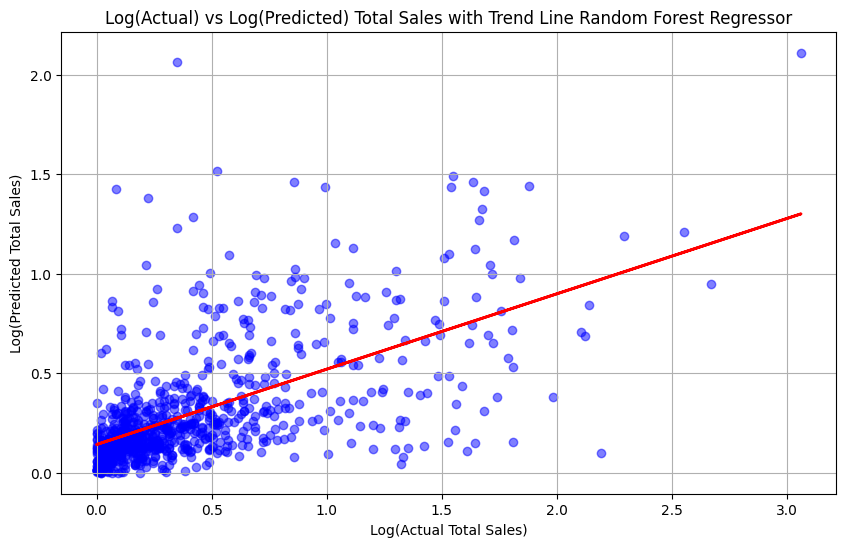

```
R-squared value: 0.2792974010449363
```

```python
# Log-transform the actual and predicted total sales
y_test_log = np.log1p(y_test)
y_pred_log = np.log1p(y_pred)

# Fit a linear regression line
slope, intercept = np.polyfit(y_test_log, y_pred_log, 1)
line = slope * y_test_log + intercept

# Plotting actual vs predicted total sales with a trend line on a log scale
plt.figure(figsize=(10, 6))
plt.scatter(y_test_log, y_pred_log, color='blue', alpha=0.5)
plt.plot(y_test_log, line, color='red', linewidth=2)
plt.xlabel('Log(Actual Total Sales)')
plt.ylabel('Log(Predicted Total Sales)')
plt.title('Log(Actual) vs Log(Predicted) Total Sales with Trend Line Random Forest Regressor')
plt.grid(True)
plt.show()

# Calculate R-squared value
r_squared = r2_score(y_test_log, y_pred_log)
print(f"R-squared value: {r_squared}")
```

```python
from sklearn.neighbors import KNeighborsRegressor

# Define model
knn_model  = Pipeline(steps=[('preprocessor', preprocessor),
                        ('regressor', KNeighborsRegressor(n_neighbors=5))])

# Train the model
knn_model .fit(X_train, y_train)

# Predictions
y_pred = knn_model .predict(X_test)

# Evaluate the model
mse = mean_squared_error(y_test, y_pred)
print(f"Mean Squared Error: {mse}")
```

```
Mean Squared Error: 1.5529656727272727
```

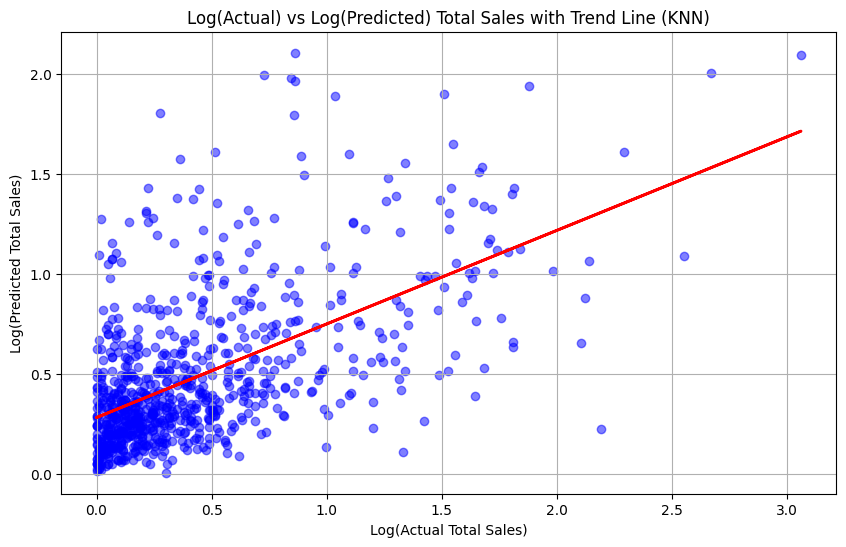

```
R-squared value: 0.27131038170548916
```

```python
# Log-transform the actual and predicted total sales
y_test_log = np.log1p(y_test)
y_pred_log = np.log1p(y_pred)

# Fit a linear regression line
slope, intercept = np.polyfit(y_test_log, y_pred_log, 1)
line = slope * y_test_log + intercept

# Plotting actual vs predicted total sales with a trend line on a log scale
plt.figure(figsize=(10, 6))
plt.scatter(y_test_log, y_pred_log, color='blue', alpha=0.5)
plt.plot(y_test_log, line, color='red', linewidth=2)
plt.xlabel('Log(Actual Total Sales)')
plt.ylabel('Log(Predicted Total Sales)')
plt.title('Log(Actual) vs Log(Predicted) Total Sales with Trend Line (KNN)')
plt.grid(True)
plt.show()

# Calculate R-squared value
r_squared = r2_score(y_test_log, y_pred_log)
print(f"R-squared value: {r_squared}")
```

### **Analysis of the Log-Transformed Actual vs. Predicted Sales**

**Random Forest Regressor:** The scatter plot shows a dense clustering of points around the lower sales values with predictions generally following the actual sales trend as indicated by the linear trend line. This model demonstrates a stronger linear relationship between predicted and actual sales, especially for lower and mid-range sales values, indicated by the closer fit of points along the trend line.

**K-Nearest Neighbors (KNN):** Similar to the Random Forest model, there is a dense clustering around lower sales values, but the spread of points away from the trend line is slightly more pronounced, especially at higher sales values. The trend line suggests that while KNN follows the overall trend well, it might struggle with accuracy at the extremes, potentially due to its sensitivity to local variations in data.

```
Cross-Validation RMSE Scores: [1.82545462 1.64839904 1.01734427 1.04961326 0.96906819]
Mean RMSE: 1.3019758763516938
```

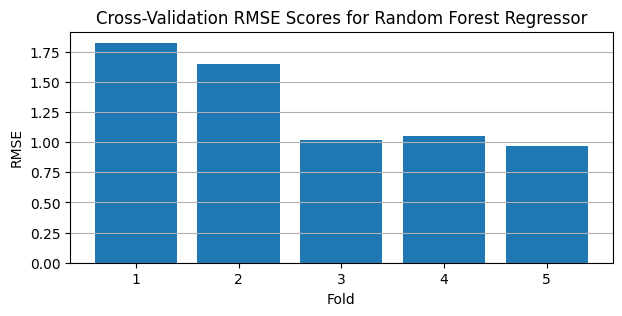

```python
from sklearn.model_selection import cross_val_score

# Define the RandomForestRegressor model
rf_model = Pipeline(steps=[('preprocessor', preprocessor),
                        ('regressor', RandomForestRegressor(n_estimators=100, random_state=42))])

# Perform cross-validation
cv_scores_rf = cross_val_score(model, X, y, cv=5, scoring='neg_mean_squared_error')

# Convert the negative MSE scores to positive and calculate RMSE
cv_rmse_scores_rf = np.sqrt(-cv_scores_rf)

# Print the RMSE scores and mean RMSE
print("Cross-Validation RMSE Scores:", cv_rmse_scores_rf)
print("Mean RMSE:", cv_rmse_scores_rf.mean())

# Plotting cross-validation RMSE scores
plt.figure(figsize=(7, 3))
plt.bar(range(1, 6), cv_rmse_scores_rf)
plt.xlabel('Fold')
plt.ylabel('RMSE')
plt.title('Cross-Validation RMSE Scores for Random Forest Regressor')
plt.grid(axis='y')
plt.show()
```

```
Cross-Validation RMSE Scores for KNN: [1.7273006  1.62028745 1.00503727 1.07073941 1.02809062]
Mean RMSE for KNN: 1.2902910677318675
```

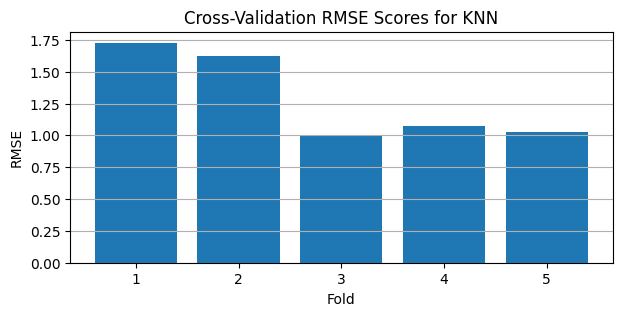

```python
from sklearn.neighbors import KNeighborsRegressor

# Define the KNeighborsRegressor model
knn_model = Pipeline(steps=[('preprocessor', preprocessor),
                            ('regressor', KNeighborsRegressor(n_neighbors=5))])

# Perform cross-validation on the KNN model
cv_scores_knn = cross_val_score(knn_model, X, y, cv=5, scoring='neg_mean_squared_error')

# Convert the negative MSE scores to positive and calculate RMSE for KNN
cv_rmse_scores_knn = np.sqrt(-cv_scores_knn)

# Print the RMSE scores and mean RMSE for KNN
print("Cross-Validation RMSE Scores for KNN:", cv_rmse_scores_knn)
print("Mean RMSE for KNN:", cv_rmse_scores_knn.mean())

# Plotting cross-validation RMSE scores for KNN
plt.figure(figsize=(7, 3))
plt.bar(range(1, 6), cv_rmse_scores_knn)
plt.xlabel('Fold')
plt.ylabel('RMSE')
plt.title('Cross-Validation RMSE Scores for KNN')
plt.grid(axis='y')
plt.show()
```

### **Analysis of the Cross-Validation RMSE Scores**

**Random Forest Regressor:** The RMSE scores across the five folds show variability, with some folds performing significantly better than others. The variation suggests that while the model generally performs well, its predictions can vary depending on the specific subset of data used, indicating potential overfitting or sensitivity to data partitioning.

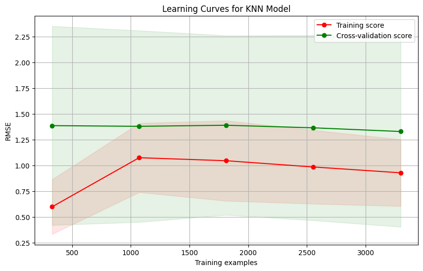

```
array([1.7273006 , 1.62028745, 1.00503727, 1.07073941, 1.02809062])
```

```python
from sklearn.model_selection import learning_curve

# Perform cross-validation on the KNN model
cv_scores_knn = cross_val_score(knn_model, X, y, cv=5, scoring='neg_mean_squared_error')

# Convert the negative MSE scores to positive and calculate RMSE for KNN
cv_rmse_scores_knn = np.sqrt(-cv_scores_knn)

# Define the learning curve parameters
train_sizes, train_scores, test_scores = learning_curve(
    knn_model, X, y, cv=5, scoring='neg_mean_squared_error',
    train_sizes=np.linspace(0.1, 1.0, 5))

# Calculate mean and standard deviation for train and test scores
train_scores_mean = -train_scores.mean(axis=1)
test_scores_mean = -test_scores.mean(axis=1)
train_scores_std = train_scores.std(axis=1)
test_scores_std = test_scores.std(axis=1)

# Convert scores to RMSE
train_rmse_scores = np.sqrt(train_scores_mean)
test_rmse_scores = np.sqrt(test_scores_mean)
train_rmse_std = np.sqrt(train_scores_std)
test_rmse_std = np.sqrt(test_scores_std)

# Plot learning curve
plt.figure(figsize=(10, 6))
plt.plot(train_sizes, train_rmse_scores, 'o-', color="r", label="Training score")
plt.plot(train_sizes, test_rmse_scores, 'o-', color="g", label="Cross-validation score")
plt.fill_between(train_sizes, train_rmse_scores - train_rmse_std,
                 train_rmse_scores + train_rmse_std, alpha=0.1, color="r")
plt.fill_between(train_sizes, test_rmse_scores - test_rmse_std,
                 test_rmse_scores + test_rmse_std, alpha=0.1, color="g")
plt.title('Learning Curves for KNN Model')
plt.xlabel('Training examples')
plt.ylabel('RMSE')
plt.legend(loc="best")
plt.grid(True)
plt.show()

# Output RMSE scores from cross-validation
cv_rmse_scores_knn
```

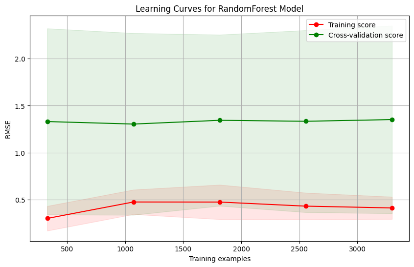

```
array([1.82545462, 1.64839904, 1.01734427, 1.04961326, 0.96906819])
```

```python
# Define the learning curve parameters for RandomForest
train_sizes_rf, train_scores_rf, test_scores_rf = learning_curve(
    rf_model, X, y, cv=5, scoring='neg_mean_squared_error',
    train_sizes=np.linspace(0.1, 1.0, 5))

# Calculate mean and standard deviation for train and test scores for RandomForest
train_scores_mean_rf = -train_scores_rf.mean(axis=1)
test_scores_mean_rf = -test_scores_rf.mean(axis=1)
train_scores_std_rf = train_scores_rf.std(axis=1)
test_scores_std_rf = test_scores_rf.std(axis=1)

# Convert scores to RMSE for RandomForest
train_rmse_scores_rf = np.sqrt(train_scores_mean_rf)
test_rmse_scores_rf = np.sqrt(test_scores_mean_rf)
train_rmse_std_rf = np.sqrt(train_scores_std_rf)
test_rmse_std_rf = np.sqrt(test_scores_std_rf)

# Plot learning curve for RandomForest
plt.figure(figsize=(10, 6))
plt.plot(train_sizes_rf, train_rmse_scores_rf, 'o-', color="r", label="Training score")
plt.plot(train_sizes_rf, test_rmse_scores_rf, 'o-', color="g", label="Cross-validation score")
plt.fill_between(train_sizes_rf, train_rmse_scores_rf - train_rmse_std_rf,
                 train_rmse_scores_rf + train_rmse_std_rf, alpha=0.1, color="r")
plt.fill_between(train_sizes_rf, test_rmse_scores_rf - test_rmse_std_rf,
                 test_rmse_scores_rf + test_rmse_std_rf, alpha=0.1, color="g")
plt.title('Learning Curves for RandomForest Model')
plt.xlabel('Training examples')
plt.ylabel('RMSE')
plt.legend(loc="best")
plt.grid(True)
plt.show()

# Output RMSE scores from cross-validation for RandomForest
cv_rmse_scores_rf
```

### **Conclusion for model approaches for different features suggesting total sales**

In conclusion, by applying these predictive models, stakeholders in the gaming industry can better anticipate sales outcomes, aiding in strategic decisions such as marketing and development. Future work may explore more sophisticated models or incorporate additional data such as user engagement metrics to further enhance predictive accuracy.

# Modelling Approach for Critic Score to Total Sales

We also want to explore the relationship between just the critic scores and total sales of video games using the K-Nearest Neighbors (KNN) regression model. The KNN model is chosen for its simplicity and effectiveness in capturing non-linear relationships without the need for complex parameter tuning. By focusing solely on critic scores as predictors, this analysis seeks to quantify how well these scores can predict sales outcomes and to what extent they reflect market success.

In addition to the KNN model, a simple linear regression trend line is also plotted to provide a baseline visualization of the relationship between critic scores and sales. This approach not only complements the KNN model with a traditional regression analysis but also highlights the potential variability and prediction accuracy when using critic scores as a standalone metric.

```python
# Selecting features and target
X = games[['critic_score']]  # Using only critic_score as feature for simplicity
y = games['total_sales']

# Splitting the dataset
X_train, X_test, y_train, y_test = train_test_split(X, y, test_size=0.2, random_state=42)

# Defining a pipeline for preprocessing and modeling
pipeline = Pipeline([
    ('scaler', StandardScaler()),  # Feature scaling
    ('knn', KNeighborsRegressor(n_neighbors=5))  # KNN regressor
])

# Train the KNN model
pipeline.fit(X_train, y_train)

# Creating an example with a specific critic score to predict sales
example = pd.DataFrame({'critic_score': [8.5]})  # Example critic score of 85

# Predicting sales for the example
predicted_sales = pipeline.predict(example)

predicted_sales
```

```
array([2.916])
```

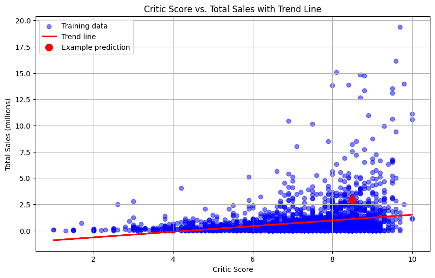

```python
# Creating a scatter plot of critic_score vs total_sales
plt.figure(figsize=(10, 6))
plt.scatter(X_train['critic_score'], y_train, color='blue', alpha=0.5, label='Training data')

# Fitting a simple linear regression to add a trend line
slope, intercept = np.polyfit(X_train['critic_score'], y_train, 1)
trend_line = slope * X_train['critic_score'] + intercept

# Plot the trend line
plt.plot(X_train['critic_score'], trend_line, color='red', linewidth=2, label='Trend line')

# Adding the example point with predicted sales
plt.scatter([8.5], predicted_sales, color='red', s=100, label='Example prediction')

# Setting up the plot
plt.xlabel('Critic Score')
plt.ylabel('Total Sales (millions)')
plt.title('Critic Score vs. Total Sales with Trend Line')
plt.legend()
plt.grid(True)
plt.show()
```

### **Analysis of the Scatter Plot**

The scatter plot of Critic Score vs. Total Sales with the trend line shows a general relationship between the critic scores of video games and their sales in millions. The data points indicate that while there's a positive correlation, the relationship isn't very strong, as evidenced by the spread of data points around the trend line. Most games, irrespective of high or moderate critic scores, tend to cluster towards the lower sales range, suggesting other factors might be influencing sales more significantly.

The trend line, plotted as a simple linear regression, suggests a modest upward trend, indicating that games with higher critic scores tend to achieve slightly higher sales. However, the vast spread of data points, especially at higher critic scores, highlights the variability in sales outcomes.

## **Conclusion for model approaches for critic score suggesting total sales**

In this analysis, we explored the relationship between video game sales and critic scores using machine learning models, specifically K-Nearest Neighbors (KNN). We preprocessed the data to handle missing values and scale numerical inputs appropriately, ensuring our models could interpret the data effectively.

Our findings indicate that while there is a positive correlation between critic scores and game sales, the relationship is weak and highly variable. This suggests that other factors such as game genre, platform exclusivity, marketing, and external economic conditions might also play significant roles in influencing game sales.

The models used, including KNN and exploratory analysis via regression plotting, provided valuable insights but also highlighted the limitations of using critic scores alone to predict sales. Future analyses could benefit from integrating additional data points such as user reviews, social media sentiment, and detailed market conditions to create more robust predictive models.

This project underscores the complexity of the video game market and the multifaceted influences on sales, suggesting a need for comprehensive analytics approaches to fully understand and predict market behaviors.